# Titanic Survival

Travis Barton

7/24/2018

This guide should serve as a first time data analysts’ stepping stone into the basic principals of statistics. Our goal will be to understand the data then, and only then, analyse and predict it.

# 1. Data Clean

### Pclass

This represents the passenger class of the ship. This should directly correlate with socioeconomic status. Let’s take a look at how they fared in terms of survival (pun intended).

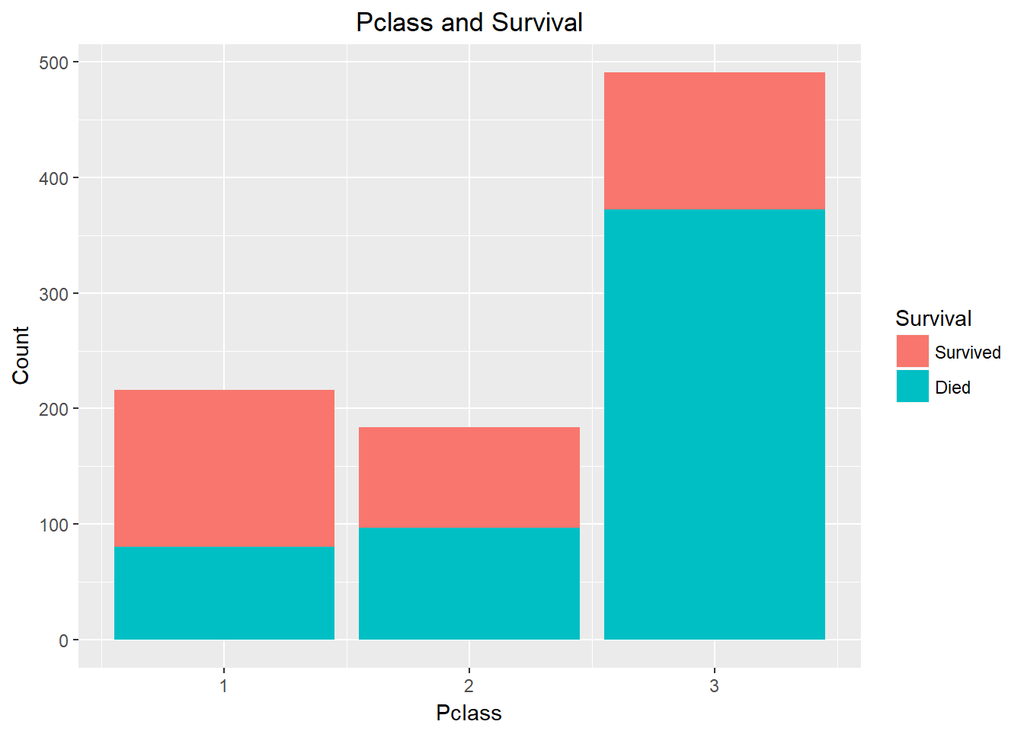

So it seems that a better passenger class corresponds with better survival which means we should keep the variable for our final model.

### Name

‘Name’ will be likely be the least helpful variable of the bunch. But that’s not to say there is nothing to be learned from it. The names themselves are not all that informative, but the titles that go along with the names will be.

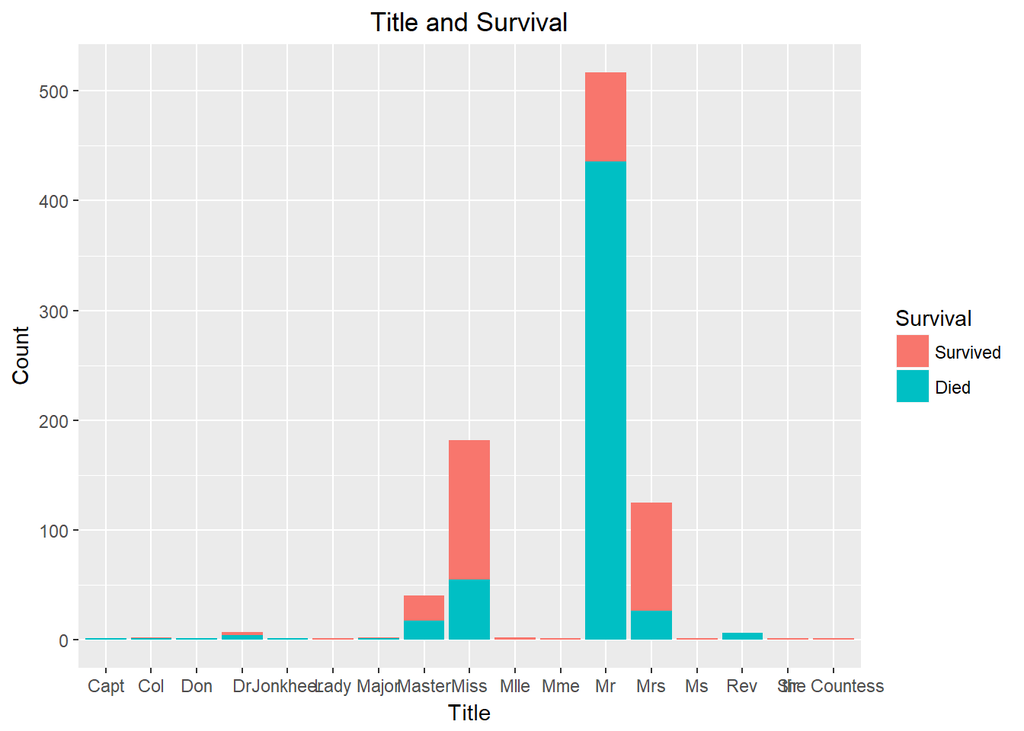

While many titles may be hard to see, ‘Mr’ seems to correlate with low survival rates, and ‘Mrs’/‘Miss’ seem to mean higher survival rates. The rest are so sparse, that we might as well combine them into their own category.

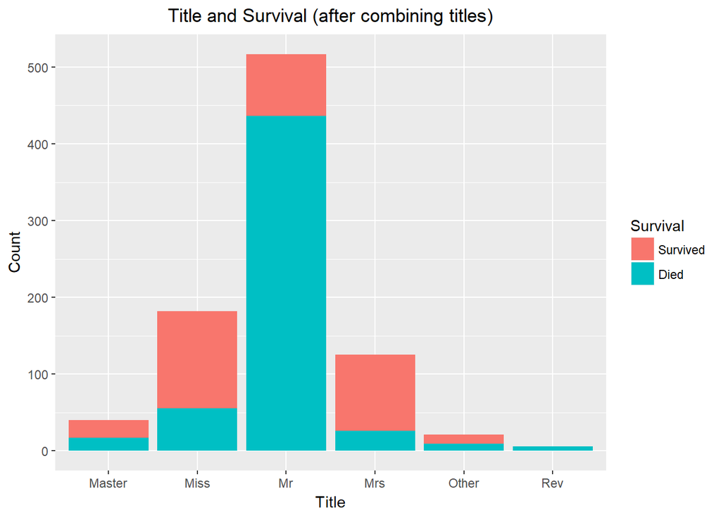

### Sex

Let’s see how sex relates to survival and how many missing values we have.

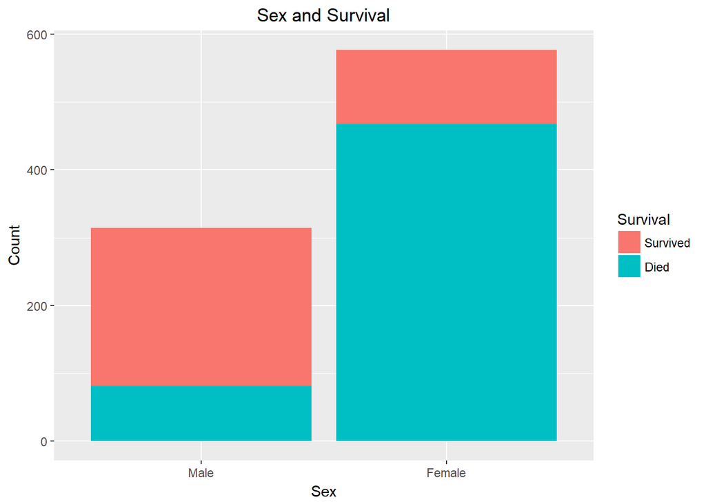

### Age

Age will be a troublesome variable with 19.86% of the values missing. With so many missing values, it would not be practical to just give them the same value (whether mean or median imputation). Doing so would cause us to miss much of the information that can be extracted.

This is where the title variable will come in. We can get a more accurate estimate of the ages of the passengers if we impute the age based on their title.

```r
Master_age <- median(train$Age[which(train$title == "Master" & is.na(train$Age) == F)])
Miss_age <- median(train$Age[which(train$title == "Miss" & is.na(train$Age) == F)])
Mr_age <- median(train$Age[which(train$title == "Mr" & is.na(train$Age) == F)])
Mrs_age <- median(train$Age[which(train$title == "Mrs" & is.na(train$Age) == F)])
Other_age <- median(train$Age[which(train$title == "Other" & is.na(train$Age) == F)])
Rev_age <- median(train$Age[which(train$title == "Rev" & is.na(train$Age) == F)])

for(i in 1:891)
{
  if(is.na(train$Age[i]) == T)
  {
    if(train$title[i] == "Master")
    {
      train$Age[i] = Master_age
    }
    else if(train$title[i] == "Miss")
    {
      train$Age[i] = Miss_age
    }
    else if(train$title[i] == "Mr")
    {
      train$Age[i] = Mr_age
    }
    else if(train$title[i] == "Mrs")
    {
      train$Age[i] = Mrs_age
    }
    else if(train$title[i] == "Other")
    {
      train$Age[i] = Other_age
    }
    else
    {
      train$Age[i] = Rev_age
    }
  }
}
```

Now that we have a more accurate estimate of the ages, let’s take a look at how they do in terms of survival.

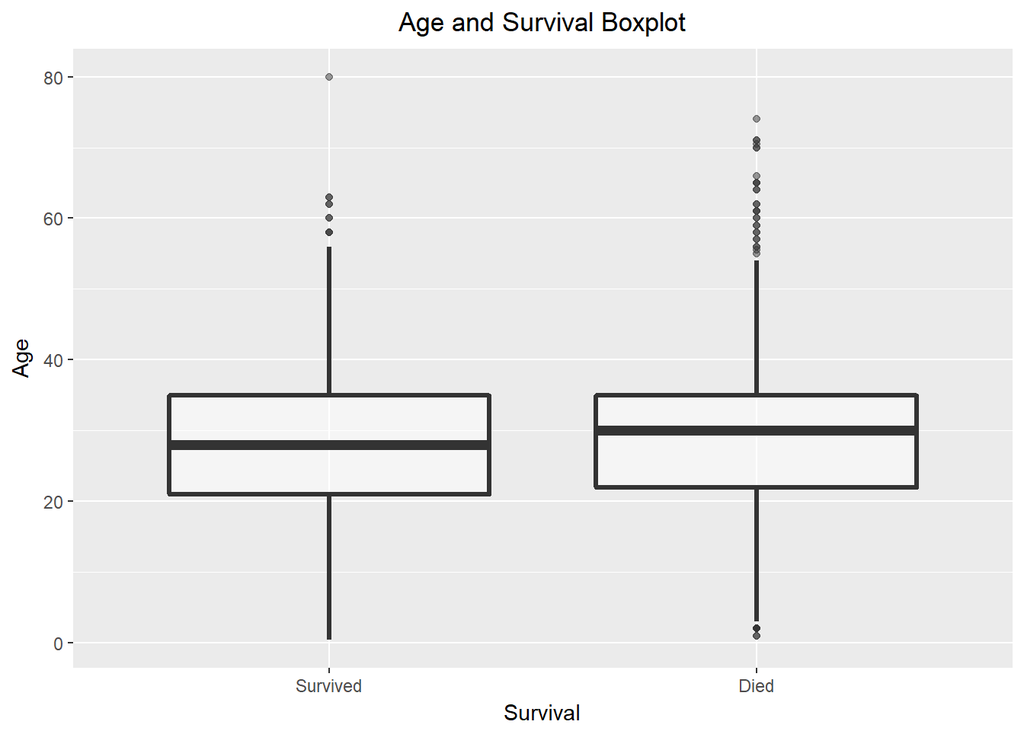

It seems that the people that survived had a slightly lower age than those who lived, but the picture is not clear. Let’s try binning the ages and see if that can clarify what is happening.

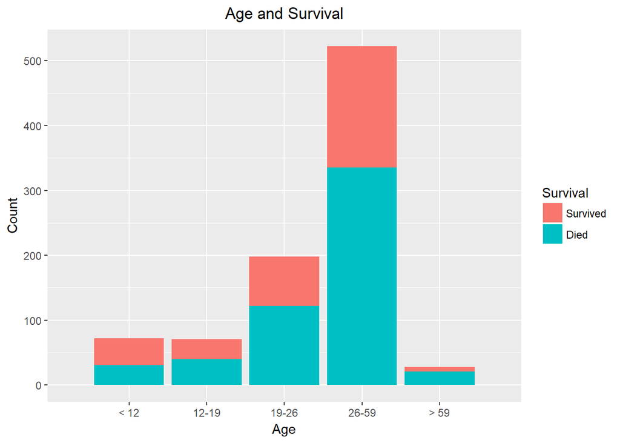

This is still not looking useful, however, age may have to be dropped.

### SibSp

This variable represents the number of siblings that a person had on board. Our thought prior to analysis is that larger families will be able to get off of the boat more easily, but let’s see what the data has to say.

```r
#barplot(table(train$Survived,train$SibSp), col = rainbow(5))
#legend("topright", fill=rainbow(5), legend=c("Survived", "Died"))
```

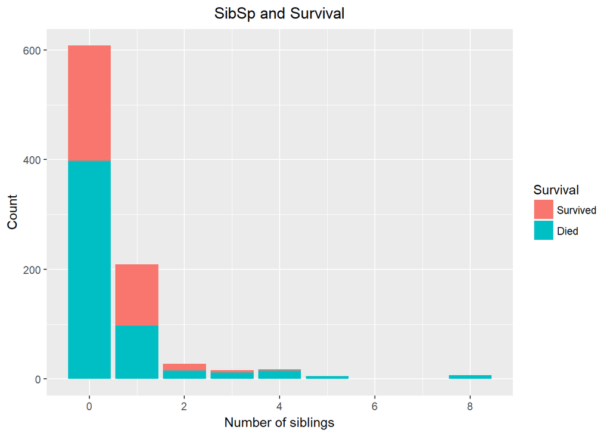

```r
#codes using train_copy for GGPLOT

sibsp_ggplot<- ggplot(data= train_copy, aes(x= train_copy$SibSp))+ geom_bar(aes(fill= Survived))
sibsp_ggplot<- sibsp_ggplot +xlab("Number of siblings") + ylab("Count")+ scale_fill_discrete(name="Survival")+
  ggtitle("SibSp and Survival")+ theme(plot.title = element_text(hjust = 0.5))

print(sibsp_ggplot)
```

### Parch

```r
#barplot(table(train$Survived, train$Parch), col = rainbow(10))
#legend("topright", fill=rainbow(10), legend=c("Survived", "Died"))
```

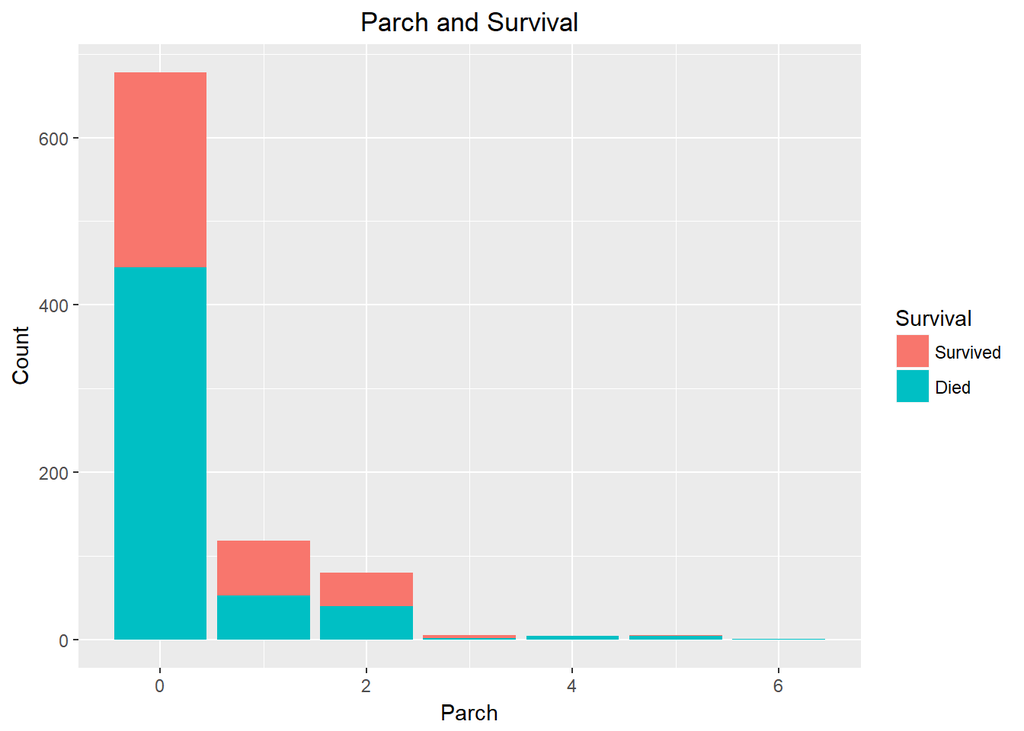

```r
#codes using train_copy for GGPLOT

parch_ggplot<- ggplot(data= train_copy, aes(x= train_copy$Parch))+ geom_bar(aes(fill= Survived))
parch_ggplot<- parch_ggplot +xlab("Parch") + ylab("Count")+ scale_fill_discrete(name="Survival")+
  ggtitle("Parch and Survival")+ theme(plot.title = element_text(hjust = 0.5))

print(parch_ggplot)
```

#### Ticket

‘Ticket’ does not seem to have any usable information. It seems the pattern may contain some hidden usefulness but we do not see it.

```r
head(train$Ticket)
```

```
## [1] "A/5 21171"        "PC 17599"         "STON/O2. 3101282"
## [4] "113803"           "373450"           "330877"
```

#### Fare

It was established by Pclass that the socioeconomic class of the passengers may contribute to their survival, and fare seems to be another good indicator of such. We suspect that it will have useful information inside of it.

There are a lot of fares, but we think they can be split up into certain categories. let’s look at which fares lead to poor survival odds and lump them together.

```r
temp <- table(train$Survived, round(train$Fare, -2))
temp2 <- temp[1,]/colSums(temp)
index <- which(temp2 < .5)
names(index) = {}
Surviving_fares <- as.numeric(colnames(temp)[index])
Dying_fares <- as.numeric(colnames(temp)[-index])

train$whichfare <- NA
index <- which(round(train$Fare, -2) %in% Surviving_fares)
train$whichfare[index] = 1

index <- which(round(train$Fare, -2) %in% Dying_fares)
train$whichfare[index] = 0
```

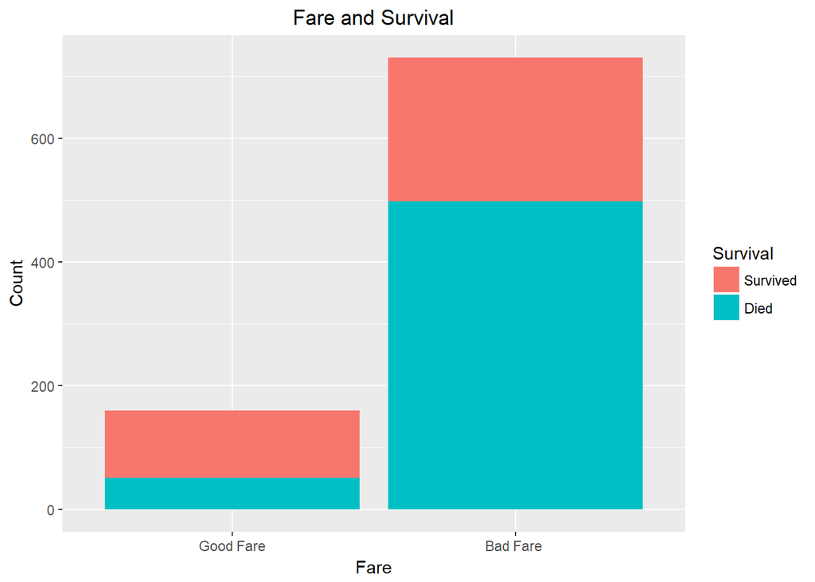

```r
#codes using train_copy for ggplot
#using the 'Survived' col from train to get the exact temps
train_copy$Survived_copy<- train$Survived

temp_copy <- table(train_copy$Survived_copy, round(train_copy$Fare, -2))
temp2_copy <- temp_copy[1,]/colSums(temp_copy)
index_copy_fare <- which(temp2_copy < .5)
names(index_copy_fare) = {}
Surviving_fares_copy <- as.numeric(colnames(temp_copy)[index_copy_fare])
Dying_fares_copy <- as.numeric(colnames(temp_copy)[-index_copy_fare])

train_copy$whichfare_copy <- NA
index_copy_fare  <- which(round(train_copy$Fare, -2) %in% Surviving_fares_copy)
train_copy$whichfare_copy[index_copy_fare] = 1

index_copy_fare  <- which(round(train_copy$Fare, -2) %in% Dying_fares_copy)
train_copy$whichfare_copy[index_copy_fare ] = 0
```

If a given fare has less than 50% chance of survival, it was labeled a “bad fare” otherwise is was a “good fare.” We decided to bin by 100s so that we would not have a group with too small of a sample size.

### Cabin

Because cabin is so sparse, we are opting to eliminate it from our data set. Over 77% of the entries are NA, and since we do not know the connection between cabin and survival, we are not comfortable trying to extrapolate from such a spare vector.

```r
length(which(is.na(train$Cabin) == T))/nrow(train)
```

```
## [1] 0.7710438
```

### Embarked

Embarked describes which port the passenger left from. This may have an impact, as different ports might pick up different kinds of passengers on average.

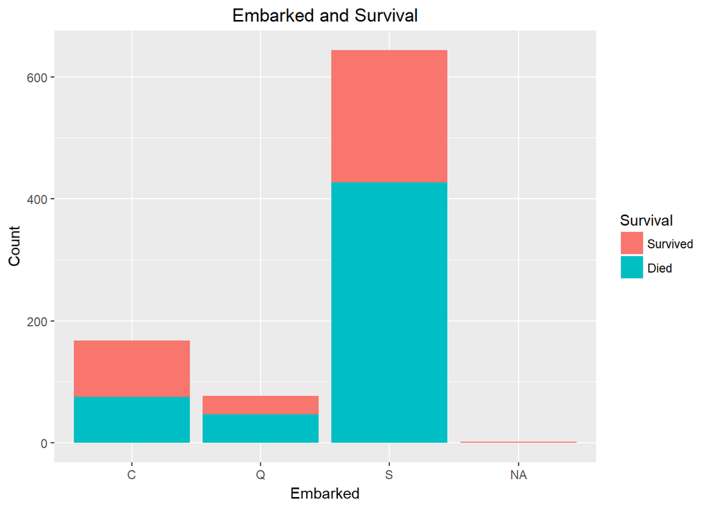

It seems that the port of takeoff matters, but there are a drastic difference in the sample sizes. This might become an issue, as the distributions with less people are not being represented to their fullest extent.

It is important to note that there are a few missing values of ‘Embarked’. However, there are not many, so we can fill in the missing values with a sample of the existing values of ‘Embarked’.

```r
index <- which(is.na(train$Embarked) == T)
set.seed(6)
train$Embarked[index] = sample(train$Embarked[-index], 2)
```

# 2. Models

Now that the data is cleaned and candidates have been chosen, it is time to make the decision of predictors and models. Some, like ‘Sex,’ are guaranteed choices based on theory and consensus. Others, like ‘Age,’ will be tested and chosen only if the models where it is included perform well. Since ‘Title’ acts as a proxy for ‘Age,’ we will use it instead initially, as it showed a much clearer distinction in its indication towards survival.

We will experiment with the following models:

- SVM
- KNN
- Random Forest
- Logistic Regression
- Linear Regression

Each will be tested with the following variables:

- Pclass
- Title
- Sex
- SibSp
- Parch
- whichfare
  - Whether they had a good fare or bad fare
- Embarked

We will make a new data set with these variables called ‘dat’ that will also turn all our factors into numbers. In this step we will also scale the columns so that they revolve around 0.

```r
#create dat
Survived <- train$Survived
dat <- cbind(train$title,  train$Pclass, train$Sex, train$SibSp, train$Parch, train$whichfare, train$Embarked)
colnames(dat) <- c("Title",  "Pclass", "Sex", "SibSp", "Parch", "Whichfare", "Embarked")
dat <- as.data.frame(dat)

dat$Title <- factor(dat$Title, labels = 1:6)
dat$Sex <- factor(dat$Sex, labels = 0:1)
dat$Embarked <- factor(dat$Embarked, labels = 1:3)

#create scaled dat
dat.scaled <- dat
for(i in 1:ncol(dat))
{
  dat.scaled[,i] = as.numeric(dat[,i])
}
dat.scaled <- scale(dat.scaled)

#re-attach sruvived
dat <- cbind(Survived, dat)
dat.scaled <- cbind(Survived, dat.scaled)
dat.scaled <- as.data.frame(dat.scaled)
```

### SVM

We are choosing to start with SVM because it is relatively easy to implement, and is generally reliable. There are ways to improve its performance that we will not pursue in this elementary example such as PCA/MCA.

Since we do not have extraordinarily large data, we will use the e1071 package. For large data sets,werecommend the liquidSVM package. We will also need to split our data into a train and test set so that we can see how our models do before we submit the data into kaggle. To do so, we wrote a little function called cross_val_maker to test our models and a function called percent to return the accuracy.

```r
#Scaled Data
set.seed(7)
Cross_val_holder <- Cross_val_maker(dat.scaled, .1)
Train.scaled <- Cross_val_holder$Train
Test.scaled <- Cross_val_holder$Test


svmfit <- svm(Survived ~ ., data = Train.scaled, type = "C-classification")
results <- predict(svmfit, Test.scaled[,-1])
cat(paste("Our accuracy for the scaled-data SVM was ", Percent(Test.scaled[,1], results)*100, "%", sep = ""))
```

Our accuracy for the scaled-data SVM was 80.8988764044944%

```r
# Normal data
set.seed(7)
Cross_val_holder <- Cross_val_maker(dat, .1)
Train.scaled <- Cross_val_holder$Train
Test.scaled <- Cross_val_holder$Test

svmfit <- svm(Survived ~ ., data = Train.scaled, type = "C-classification")
results <- predict(svmfit, Test.scaled[,-1])
cat(paste("Our accuracy for the nonscaled-data was: ", Percent(Test.scaled[,1], results)*100, "%", sep = ""))
```

Our accuracy for the nonscaled-data was: 77.5280898876404%

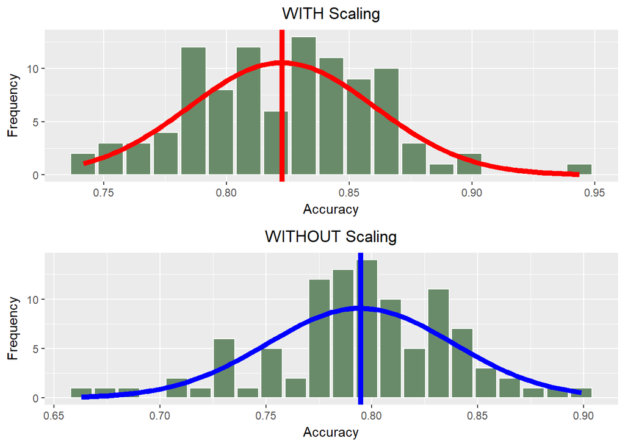

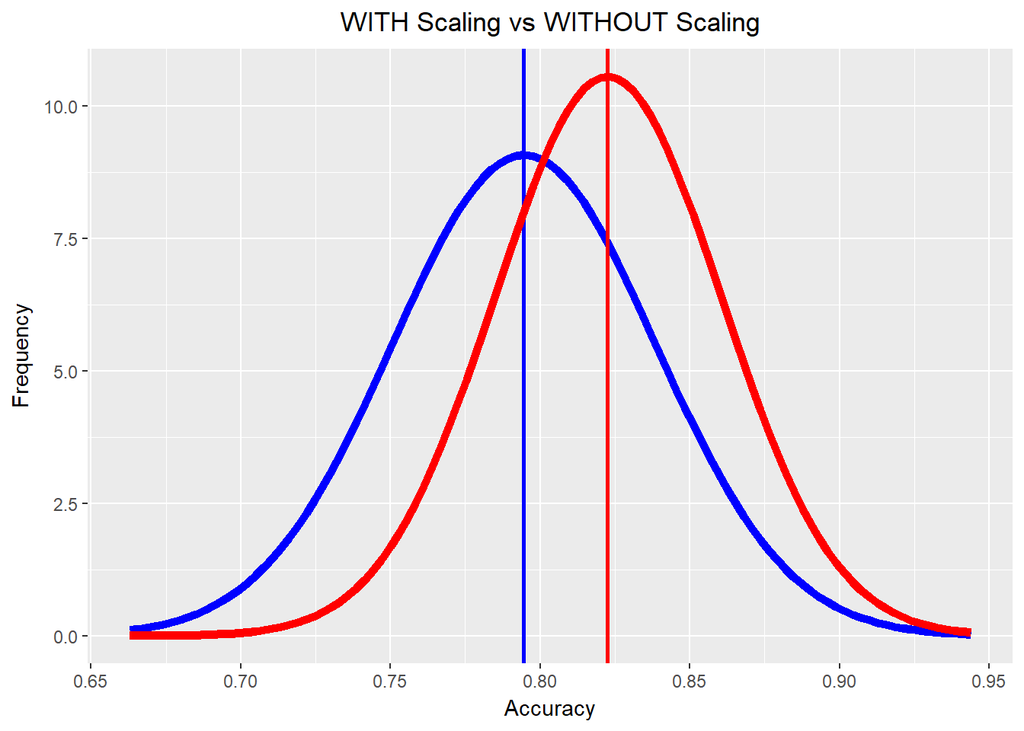

### KNN

K nearest neighbor is another geometric process that does not necessarily need scaling before it achieves a good level of accuracy. It generally works well when there are tight, dense clusters of our data.

Since we are not going to be working with extraordinarily large data, we will use the package ‘class.’ If we were to be working with extra large data, we would recommend the ‘FNN’ (Fast Nearest Neighbor) package.

```r
#Scaled Data
set.seed(8)
Cross_val_holder <- Cross_val_maker(dat.scaled, .1)
Train.scaled <- Cross_val_holder$Train
Test.scaled <- Cross_val_holder$Test

knnfit <- knn(Train.scaled[,-1], Test.scaled[,-1], Train.scaled[,1], k = 5)
cat(paste("Our accuracy with scaled-data knn was: ",Percent(Test.scaled[,1], knnfit)*100, "%", sep = ""))
```

Our accuracy with scaled-data knn was: 80.8988764044944%

```r
set.seed(9)
Cross_val_holder <- Cross_val_maker(dat, .1)
Train.scaled <- Cross_val_holder$Train
Test.scaled <- Cross_val_holder$Test

knnfit <- knn(Train.scaled[,-1], Test.scaled[,-1], Train.scaled[,1], k = 5)
cat(paste("Our accuracy with nonscaled-data knn was: ",Percent(Test.scaled[,1], knnfit)*100, "%", sep = ""))
```

Our accuracy with nonscaled-data knn was: 85.3932584269663%

Interestingly enough, the non-scaled data shows better results than the scaled data. let’s see if this is just an artifact of luck with repeated sampling.

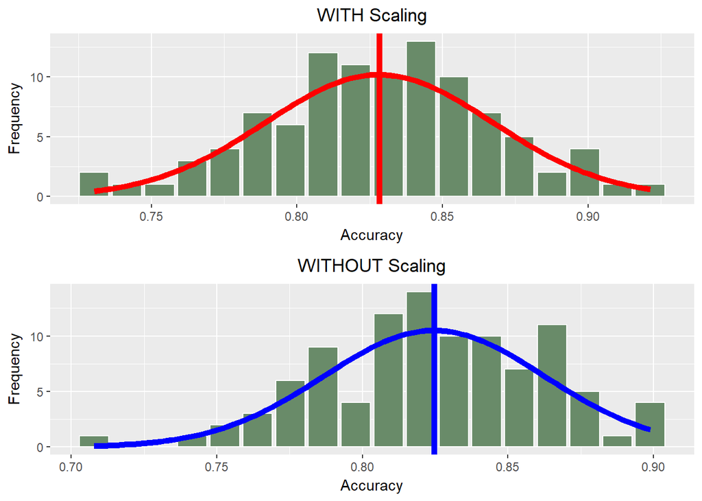

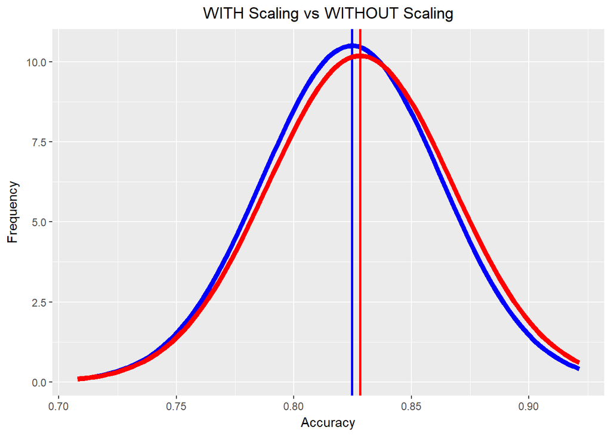

### Random Forest

Random forest is a technique that usually works best when we have a large amount of predictors, with many of them not being practical. We often use random forest to identify key predictors when there are too many to reasonably to forward and backward regression with. In this case, though, we will be using it for prediction. While we will be using the ‘RandomForest’ package, we recommend using the ‘Ranger’ package when you have a lot of data.

```r
set.seed(9)
Cross_val_holder <- Cross_val_maker(dat.scaled, .1)
Train.scaled <- Cross_val_holder$Train
Test.scaled <- Cross_val_holder$Test

rffit <- randomForest(factor(Survived)~., data = Train.scaled, mtry = 4)
results <- predict(rffit, Test.scaled[,-1])
cat(paste("Our accuracy for scaled-data random forest is: ",Percent(Test.scaled[,1], results)*100, "%", sep = ""))
```

```
## Our accuracy for scaled-data random forest is: 84.2696629213483%
```

```r
set.seed(10)
Cross_val_holder <- Cross_val_maker(dat, .1)
Train.scaled <- Cross_val_holder$Train
Test.scaled <- Cross_val_holder$Test

rffit <- randomForest(factor(Survived)~., data = Train.scaled, mtry = 4)
results <- predict(rffit, Test.scaled[,-1])
cat(paste("Our accuracy for scaled-data random forest is: ",Percent(Test.scaled[,1], results)*100, "%", sep = ""))
```

```
## Our accuracy for scaled-data random forest is: 79.7752808988764%
```

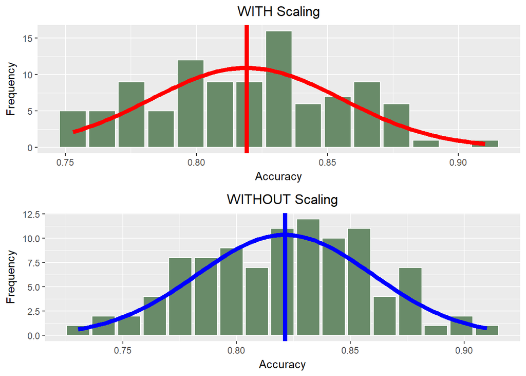

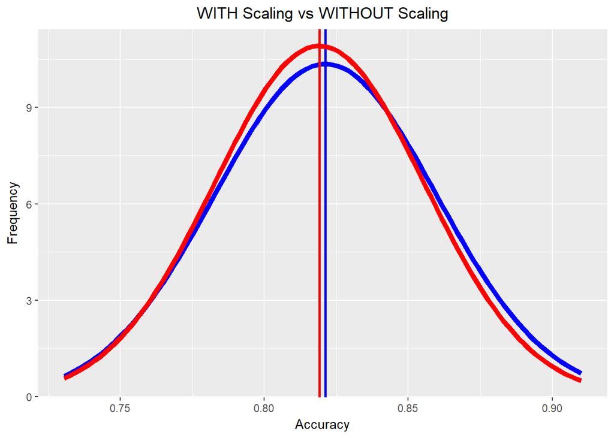

It looks like the data is most effective for random forest when it is not scaled. This does not surprise us, as when we scale, we take away a little bit of the distinctiveness of the columns, thus pulling the different trees that make up the random forest model a little closer together. However the difference in the means is very slight.

### Logistic Regression

```r
set.seed(11)
Cross_val_holder <- Cross_val_maker(dat.scaled, .1)
Train.scaled <- Cross_val_holder$Train
Train.scaled$Survived <- factor(Train.scaled$Survived)
Test.scaled <- Cross_val_holder$Test
Test.scaled$Survived <- factor(Test.scaled$Survived)

fitLR <- glm(Survived~., data = Train.scaled, family = "binomial")
results <- predict(fitLR, Test.scaled[,-1], type = "response")
cat(paste("Our accuracy for scaled-data logistic regresion is: ",Percent(Test.scaled[,1], round(results)), "%", sep = ""))
```

```
## Our accuracy for scaled-data logistic regresion is: 0.764044943820225%
```

```r
set.seed(12)
Cross_val_holder <- Cross_val_maker(dat, .1)
Train.scaled <- Cross_val_holder$Train
Train.scaled$Survived <- factor(Train.scaled$Survived)
Test.scaled <- Cross_val_holder$Test
Test.scaled$Survived <- factor(Test.scaled$Survived)

fitLR <- glm(Survived~., data = Train.scaled, family = "binomial")
results <- predict(fitLR, Test.scaled[,-1], type = "response")
cat(paste("Our accuracy for nonscaled-data logistic regresion is: ",Percent(Test.scaled[,1], round(results)), "%", sep = ""))
```

```
## Our accuracy for nonscaled-data logistic regresion is: 0.876404494382023%
```

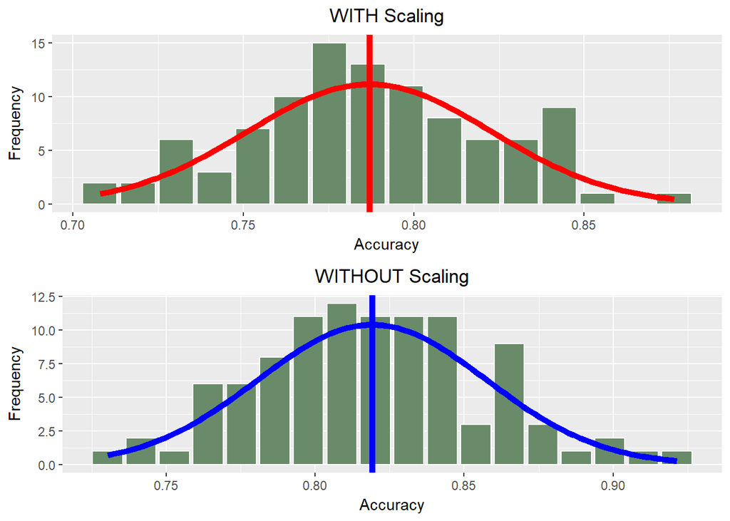

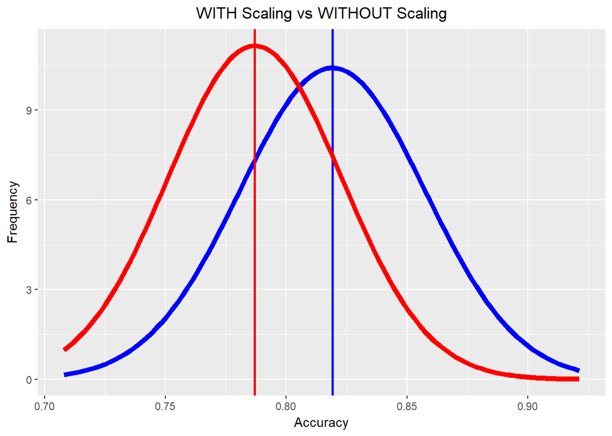

### Linear Regression

I am including the linear regression model for a baseline ‘bad’ predictor. We do not anticipate the linear model doing well, as linear models are meant for continuous response variables. Since we have a binary response variable, this model should have an extremely high variance and a low accuracy.

```r
set.seed(12)
Cross_val_holder <- Cross_val_maker(dat.scaled, .1)
Train.scaled <- Cross_val_holder$Train
Train.scaled$Survived <- factor(Train.scaled$Survived)
Test.scaled <- Cross_val_holder$Test
Test.scaled$Survived <- factor(Test.scaled$Survived)

fitLR <- lm(Survived~., data = Train.scaled)
results <- predict(fitLR, Test.scaled[,-1])
cat(paste("Our accuracy for scaled-data logistic regresion is: ",Percent(Test.scaled[,1], round(results)), "%", sep = ""))
```

```
## Our accuracy for scaled-data logistic regresion is: 0.831460674157303%
```

```r
set.seed(12)
Cross_val_holder <- Cross_val_maker(dat, .1)
Train.scaled <- Cross_val_holder$Train
Train.scaled$Survived <- factor(Train.scaled$Survived)
Test.scaled <- Cross_val_holder$Test
Test.scaled$Survived <- factor(Test.scaled$Survived)

fitLR <- lm(Survived~., data = Train.scaled)
results <- predict(fitLR, Test.scaled[,-1])
cat(paste("Our accuracy for nonscaled-data logistic regresion is: ",Percent(Test.scaled[,1], round(results)), "%", sep = ""))
```

```
## Our accuracy for nonscaled-data logistic regresion is: 0.876404494382023%
```

So, initially, the linear model seems to be doing as expected with the scaled data, but performed surprisingly well with the non scaled data. We suspect that this is just a random success, but let’s see how it looks after repeated sampling.

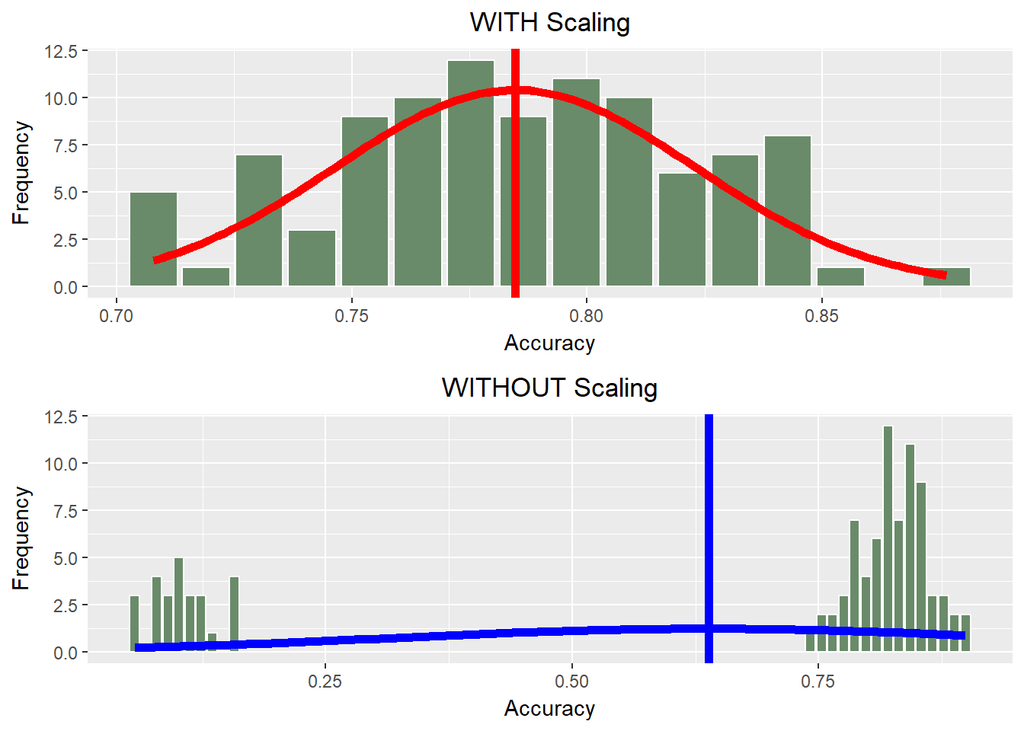

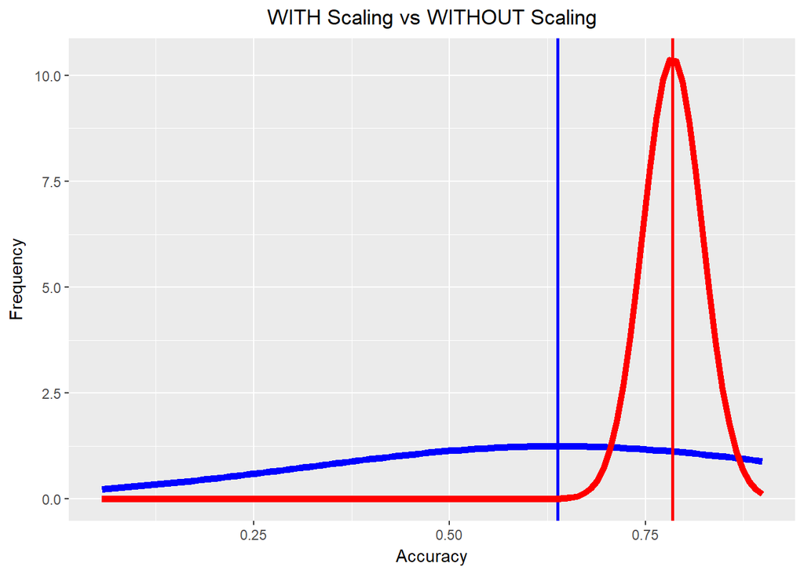

As suspected, the previous success rate was mostly due to random chance. The reason that the data without scaling is so bi-modal, is that we are trying to give a linear regression model only 2 outputs. Thus, its slope is allowed to swing widely about its center depending on any particular training sample. Since the scaled data is much more clustered, it does not have as much of a wild swing, but it still performs terribly.

# Making the data ‘Kaggle ready’

We have to prepare the testing data in the same way that we prepared the training data. We will not show this, as it is just re-doing the process inside of ‘data clean.’ The final step is to make our predictions from each model kaggle ready. To do that, we need our predictions concatenated with the id for each prediction.

```r
#There is an issue with the levels of parch matching, sowewill make them numeric. This is a bit of a band-aid but it should not effect the outcome to much.

dat$Parch <- as.numeric(dat$Parch)
dat.test$Parch <- as.numeric(dat.test$Parch)

# SVM
fitsvm <- svm(Survived ~., data = dat, type = "C-classification")
fitsvm.scaled <- svm(Survived ~., data = dat.scaled, type = "C-classification")


svmpred <- predict(fitsvm, dat.test)
svmpred.scaled <- predict(fitsvm.scaled, dat.test.scaled)


#write_csv(svm_Submission <- data.frame("PassengerId" = 892:1309, "Survived" = svmpred), "SVM.csv")
#write_csv(svm_Submission <- data.frame("PassengerId" = 892:1309, "Survived" = svmpred.scaled), "SVM_scaled.csv")


# rf

fitrf <- knn(train = dat[,-1], test = dat.test, cl = dat[,1], k = 5)
fitknn.scaled <- knn(train = dat.scaled[,-1], test = dat.test.scaled, cl = dat.scaled[,1], k = 5)

#write_csv(svm_Submission <- data.frame("PassengerId" = 892:1309, "Survived" = fitknn), "KNN.csv")
#write_csv(svm_Submission <- data.frame("PassengerId" = 892:1309, "Survived" = fitknn.scaled), "KNN_scaled.csv")

# Random Forest

fitrf <- randomForest(factor(Survived) ~., data = dat, mtry = 4)
fitrf.scaled <- randomForest(factor(Survived) ~., data = dat.scaled, mtry = 4)

rfpred <- predict(fitrf, dat.test)
rfpred.scaled <- predict(fitrf.scaled, dat.test.scaled)

#write_csv(svm_Submission <- data.frame("PassengerId" = 892:1309, "Survived" = rfpred), "RF.csv")
#write_csv(svm_Submission <- data.frame("PassengerId" = 892:1309, "Survived" = rfpred.scaled), "RF_scaled.csv")


# Logsitic regression

fitlr <- glm(Survived~., data = dat, family = "binomial")
fitlr.scaled <- glm(Survived~., data = dat.scaled, family = "binomial")

lrpred <- round(predict(fitlr, dat.test, type = "response"))
lrpred.scaled <- round(predict(fitlr.scaled, as.data.frame(dat.test.scaled), type = "response"))

#write_csv(svm_Submission <- data.frame("PassengerId" = 892:1309, "Survived" = lrpred), "LR.csv")
#write_csv(svm_Submission <- data.frame("PassengerId" = 892:1309, "Survived" = lrpred.scaled), "LR_scaled.csv")


# Linear Regression

fitlinr <- lm(Survived~., data = dat)
fitlinr.scaled <- lm(Survived~., data = dat.scaled)

linrpred <- round(predict(fitlinr, dat.test))
linrpred.scaled <- round(predict(fitlinr.scaled, as.data.frame(dat.test.scaled)))

#write_csv(svm_Submission <- data.frame("PassengerId" = 892:1309, "Survived" = linrpred), "LinR.csv")
#write_csv(svm_Submission <- data.frame("PassengerId" = 892:1309, "Survived" = linrpred.scaled), "LinR_scaled.csv")
```

# Results

Here is how we did:

| Model | ACC |
| --- | --- |
| SVM | 79.425 % |
| **SVM_scaled** | **80.861 %** |
| KNN | 75.598 % |
| KNN_scaled | 75.119 % |
| RF | 75.119 % |
| RF_scaled | 75.119 % |
| Logistic | 76.555 % |
| Logistic_scaled | 74.641 % |
| Linear | 77.033 % |
| Linear_scaled | 72.727 % |

We are surprised that Logistic regression did so poorly and that linear regression did so well. We are not surprised that scaled SVM worked the best. We hope you enjoyed this walk-through and were able to make predictions of your own.

Cheers,

WBB Predictions

```r
#https://www.tutorialspoint.com/r/r_mean_median_mode.htm
#https://stackoverflow.com/questions/9981929/how-to-display-all-x-labels-in-r-barplot
#https://www.kaggle.com/tysonni/extracting-passenger-titiles-in-r
#https://www.kaggle.com/nadintamer/titanic-survival-predictions-beginner
#https://stat.ethz.ch/R-manual/R-devel/library/stats/html/ksmooth.html
```